# 1 Pesquisa eleitoral

## 1.1 Objetivo

Introduzir os visitantes da mostra as idéias de amostragem e estimação de proporções e como elas são utilizadas no nosso dia a dia.

[figure not shown]

[figure not shown]

Figure 1.1: Imagens do experimento

## 1.2 Motivação

Temos uma caixa com 200 bolas, é dito que as bolas podem ser brancas ou vermelhas porem a proporção é desconhecida, assuma que seu desafio é descobrir qual é a proporção de bolas vermelhas na caixa e são te oferecidas duas opções retirar 12 ou 60 bolas, qual opção você escolheria?

## 1.3 Construção

Para a costrução desse experimento é altamente recomendado o envolvimento de uma marceneiro pois o mesmo tera ferramentas que facilitaram o processo.

Basicamente é necessário uma caixa de madeira que será fixada a um apoio de tal forma que ela possa ser inclinada a um pouco mais que 100 graus, sendo a mesma dividida em duas seções cada uma com 200 bolinhas, 150 vermelhas e 50 brancas, com uma seção tendo 12 concavidades, lugar onde as bolinhas vão se alocar quando a caixa for inclinada, e outra tendo 60, pôr fim a caixa será fechada por um pedaço retangular de plástico transparente com o intuito de evitar que as bolinhas caiam ainda possibilitando a visualização do que acontece dentro da mesma.

## 1.4 Execução

Podemos começar indagando os visitantes da mostra com uma questão semelhante a descrita na seção 1.2, em seguida inclinamos a caixa algumas vezes (retiramos algumas amostras) e mostramos que o lado com a amostra de tamanho 60 estima a proporção de forma mais precisa que o lado com a amostra de tamanho 12.

## 1.5 Teoria

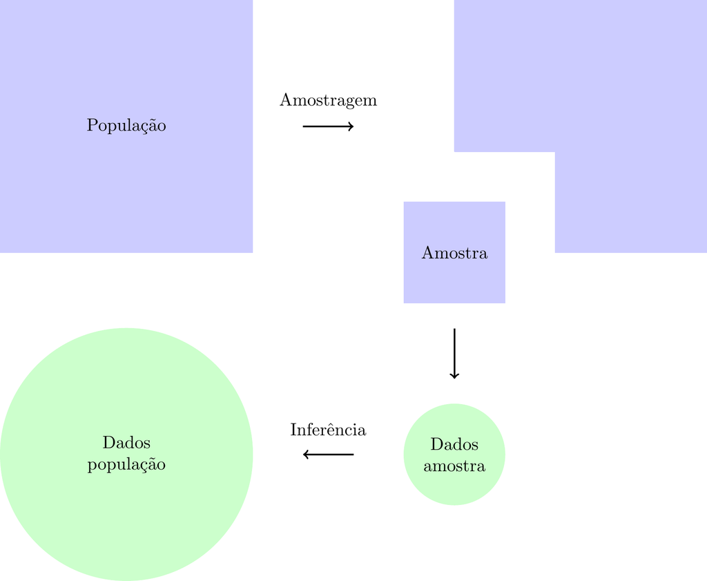

Figure 1.2: Processo de amostragem e inferência.

### 1.5.1 Plano amostral e estimação de proporção

O plano amostral determina o conjunto de regras e ações utilizadas para seleção de um elemento da população para a amostra, no plano *AASs*, *amostragem aleatória simples sem reposição*, todos os elementos da população tem mesma probabilidade de ser selecionados para amostra e cada elemento só pode ser sorteado uma vez, por isso sem reposição.

Seja $S$ nossa população que é composta por 200 bolas, 150 vermelhas e 50 brancas.

Suponha que a proporção de bolas vermelhas dessa população não é conhecida e desejamos estima-lá.

Sejam $s_1$ e $s_2$ amostras de $S$, retiradas de maneira independente e pelo plano amostral *AASs*, com tamanhos 12 e 60 respectivamente.

Denotando por $\hat{p}$ o estimador não viesado da proporção populacional no plano *AASs*, temos:

$$\begin{equation}
\hat{p} = \frac{m}{n} \tag{1.1}
\end{equation}$$

Onde $m$ é o número de elementos da amostra que possuem a característica que queremos calcular a proporção e $n$ o número total de elementos contidos na amostra.

$$\begin{equation}
var[ \hat{p} ] = \biggl( \frac{1}{n} - \frac{1}{N} \biggr)\frac{N}{N-1}p(1-p) = \biggl( \frac{N-n}{n} \biggr)\frac{1}{N-1}p(1-p) \tag{1.2}
\end{equation}$$

Observando o lado esquerdo da equação (1.2) podemos perceber que quanto maior for $n$ menor será a variância do estimador $\hat{p}$.

Como $p(1-p) \neq 0$, temos:

$$\frac{var[\hat{p}_{s_1}]}{var[\hat{p}_{s_2}]}= \frac{\biggl( \frac{1}{12} - \frac{1}{200} \biggr)\frac{200}{199}p(1-p)}{\biggl( \frac{1}{60} - \frac{1}{200} \biggr)\frac{200}{199}p(1-p)} \approx 6.71$$
Logo a variância do estimador $\hat{p}$ na amostra $s_1$ é aproximadamente 6.71 vezes maior do que a variância do mesmo na amostra $s_2$.

### 1.5.2 Simulação no R

Simulando a retirada independente seguido pelo cálculo de $\hat{p}$ para 70 amostras de tamanho 12 e 60 obtemos os seguintes gráficos.

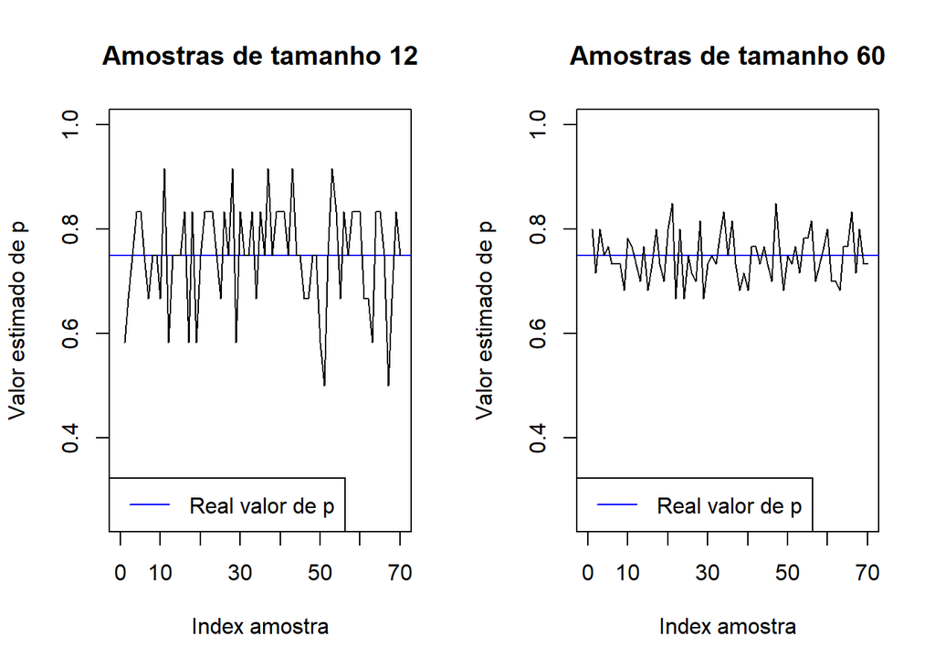

Figure 1.3: Comparação entre os valores estimados para p.

Ao observar os dois gráficos da figura 1.3 podemos perceber que os valores estimados por $\hat{p}$ nas amostras de tamanho 12 estão em geral mais distantes do valor real de $p$ do que os valores estimados nas amostras de tamanho 60.

## 1.6 Referências e leituras complementares

**Pedro Luis do Nascimento Silva, Antonio José Ribeiro Dia, Zélia Magalhães Bianchini**. “Amostragem : teoria e prática usando R”, disponível em https://amostragemcomr.github.io/livro/

**Heleno Bolfarine e Wilton O. Bussab**. “Elementos de Amostragem”.